# Going Beyond scRepertoire v1.3.1.

Nick Borcherding

Washington University in St. Louis, School of Medicine, St. Louis, MO, USA

ncborch@gmail.com

June 29th, 2021

#### Package

scRepertoire 1.3.2

# 1 Introduction

This vignette is an attempt at showing interesting analytical approaches after the immune receptor information has been added to the meta data of the single-cell object using `combineExpression()`. In order to keep the number of dependencies down, I have not made these functions in scRepertoire, but have included them here. Please see the introduction [vignette](https://ncborcherding.github.io/vignettes/vignette.html) for the scRepertoire package that does through the basic functions and parameters built within scRepertoire.

## 1.1 Loading Libraries

```r
suppressMessages(library(scRepertoire))
suppressMessages(library(Seurat))
```

## 1.2 Getting and Attaching Data

```r
combined <- combineTCR(contig_list,
                samples = c("PY", "PY", "PX", "PX", "PZ","PZ"),
                ID = c("P", "T", "P", "T", "P", "T"), cells ="T-AB")

seurat <- get(load("/Users/nick/seurat2.rda"))

seurat <- combineExpression(combined, seurat,
            cloneCall="gene", groupBy = "sample", proportion = TRUE)
```

# 2 Differential Gene Expression

We can simply use cloneType or the binning of the relative proportion of clonotypes in the `FindAllMarkers()` function from seurat.

```r
Idents(seurat) <- "cloneType"

diff.markers <- FindAllMarkers(seurat)
```

Another way to go about the differential analysis is to pick a group or groups to compare.

```r
seurat[["clonotype.of.interest"]] <- "Neg"
seurat$clonotype.of.interest <- ifelse(seurat$CTaa == "CAVNGGSQGNLIF_CSAEREDTDTQYF", "Pos", seurat$clonotype.of.interest)

Idents(seurat) <- "clonotype.of.interest"
diff.markers2 <- FindMarkers(seurat, ident.1 = "Pos", ident.2 = "Neg")
```

# 3 Regressing Clonotype

There is a high degree of overlap in the feature space of expanded clonotypes, not only in the adaptive receptor genes that form the clonotype, but also in potentially functional genes. In order to identify divergent clusters in shared clonotypes, we can regress out the effects of the expanded clonotypes on the feature space by first removing the adaptive receptor genes from the variable gene list and then using the [Harmony R package](https://github.com/immunogenomics/harmony) to re-integrate/re-embed the single-cell data using the clonotype variable as a correcting factor.

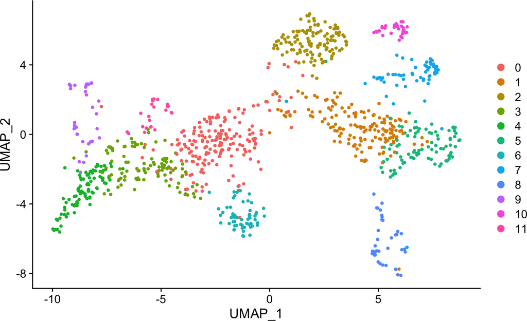

```r
Idents(seurat) <- "seurat_clusters"
library(harmony)
#To save space, the example Seurat only includes the integrated RNA values.
#In order to regress out the effects of the clonotype, we need the RNA values
#For the purposes of this demonstration, we are just going to assign the RNA
#assay as the integrated assay, please don't to this for your data
seurat[["RNA"]] <- seurat@assays$integrated

#Removing immune receptor genes from the list of variable genes
unwanted_genes <- "^IGHV*|^IGHJ*|^IGHD*|^IGKV*|^IGLV*|^TRBV*|^TRBD*|^TRBJ*|^TRDV*|^TRDD*|^TRDJ*|^TRAV*|^TRAJ*|^TRGV*|^TRGJ*"
remove_genes <- seurat[["RNA"]]@var.features %in% unwanted_genes
seurat[["RNA"]]@var.features = seurat[["RNA"]]@var.features[!remove_genes]

#Quick Sampling just so it does not take too long
set.seed(123)
sample <- sample(nrow(seurat[[]]), 1000)
subset <- subset(seurat, cells = rownames(seurat[[]])[sample])

#Running Harmony (regressing CDR3 aa and patient)
groupVariable <- c("CTaa", "Patient")
subset <- RunHarmony(subset, groupVariable, verbose = FALSE)
subset <- RunUMAP(subset, reduction = "harmony", dims = 1:20, reduction.key = "rcUMAP_", reduction.name = "regressClone")

DimPlot(subset, reduction = "umap")
```

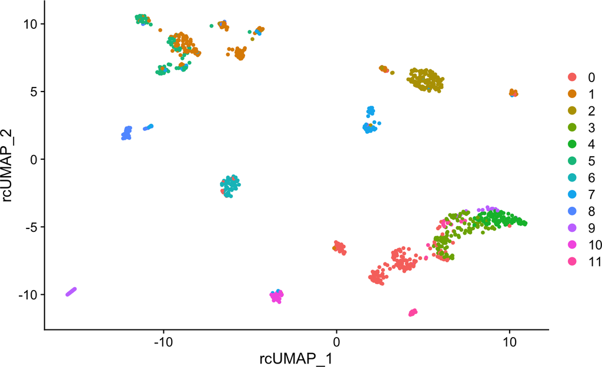

```r
DimPlot(subset, reduction = "regressClone")
```

***

# 4 Conclusion

My plan is to continually update this vignette with additional requests by users that does not necessarily fit within the scope of scRepertoire. If you have any questions, comments or suggestions, feel free to visit the github repository or email me.